# Milestone Report

Khoa Tran

01/09/2020

## Library

Load the needed library taht we going to use

```r
library(tidyverse)
library(tidytext)
library(tm)
library(dplyr)
# stemDocument
library(SnowballC)
library(tokenizers)
```

## Download data

Download the dataset using the url and store them in a Data folder

```r
if(!file.exists("Data")){dir.create("Data")}
fileName <- "Coursera-SwiftKey.zip"
path <- getwd()
if(!file.exists(paste(path,"/Data","/",fileName,sep = ""))){
        url <- "https://d396qusza40orc.cloudfront.net/dsscapstone/dataset/Coursera-SwiftKey.zip"
        download.file(url,destfile = paste(path,"/Data","/",fileName,sep = ""))
        unzip(paste(path,"/Data","/",fileName,sep = ""),exdir = paste(path,"/Data", sep =""))
        }
```

## Preprocess

The file contain 3 txt dataset that been collect from 3 different source. Since the dataset large, we will sample 10% from each of them a combine into a big text dataset

```r
filepath <- list.files(path = paste(getwd(),"/Data/final/en_US",sep = "") , pattern="*.txt", full.names=TRUE, recursive=FALSE)


lines<- lapply(filepath, function(x) {

        con <- file(x, "r")
        line <- readLines(con)
        set.seed(123)
        close(con)
        line <- sample(line,length(line)*0.1)
        text_df <- tibble(id = 1:length(line), text = line)
        text_df <- mutate(text_df, text = text_df$text)
        return(text_df)
})
str(lines)
```

```
## List of 3
##  $ : tibble [89,928 x 2] (S3: tbl_df/tbl/data.frame)
##   ..$ id  : int [1:89928] 1 2 3 4 5 6 7 8 9 10 ...
##   ..$ text: chr [1:89928] "The bruschetta however, missed the mark. Instead of manageable two-bite crostini, these were huge slices of gri"| __truncated__ "Walden Pond, Mt. Rainier, Big Sur, Everglades and so forth;" "Despite laws banning cell phones while driving and increased awareness of the d…
##  $ : tibble [7,725 x 2] (S3: tbl_df/tbl/data.frame)
##   ..$ id  : int [1:7725] 1 2 3 4 5 6 7 8 9 10 ...
##   ..$ text: chr [1:7725] "\"We've been in every game so far this season and tonight we found a way to finish and get the win,\" Preds coa"| __truncated__ "For those who went to Europe or other overseas destinations, the dollar took a steep upturn, rising sharply to "| __truncated__ "Union leaders…
##  $ : tibble [236,014 x 2] (S3: tbl_df/tbl/data.frame)
##   ..$ id  : int [1:236014] 1 2 3 4 5 6 7 8 9 10 ...
##   ..$ text: chr [1:236014] "just wanted to thank you & ask what got you started on your mission?" "Right when I thought I was done... I ran of \"sugar\" for the last dessert" "I tell ion gaf so why test my tolerance?" "mayfly? Wish I was there. :)" ...
```

Our dataset is a list of 3 simple dataframes or tibbles, each contain a text example

As we can see, our data is quiet messy, we have some cleaning that we need to do. We gonna use a special data type call Corpus to contain the text set

```r
lines_corpus <- Corpus(VectorSource(lines))
# remove lines to save memory since we do not need it anymore
rm(lines)
lines_corpus
```

```
## <<SimpleCorpus>>
## Metadata:  corpus specific: 1, document level (indexed): 0
## Content:  documents: 3
```

Now come the cleaning part

```r
# convert text to lower
lines_corpus <- tm_map(lines_corpus,tolower)
# remove punctuation
lines_corpus <- tm_map(lines_corpus, removePunctuation)
# function to remove url
removeURL <- function(x) gsub("http[^[:space:]]*", "", x)
lines_corpus <- tm_map(lines_corpus, content_transformer(removeURL))
# remove non-english word
removeNumPunct <- function(x) gsub('[^a-zA-Z|[:blank:]]', "", x)
lines_corpus <- tm_map(lines_corpus, content_transformer(removeNumPunct))
# remove stopwords
lines_corpus <- tm_map(lines_corpus, removeWords,stopwords("english"))
# strip white space
lines_corpus <- tm_map(lines_corpus, stripWhitespace)
# stemming the words
lines_corpus <- tm_map(lines_corpus, stemDocument)
# finally remove profanity
profanity <- read.csv("profanityWords.txt")$V1
lines_corpus <- tm_map(lines_corpus, removeWords, profanity)
rm(profanity)
```

## Analysis

After we do all the cleaning, lets take a look into our new data set

We going to tokenize the set with different 1-grams(unigram), 2-grams, 3-grams method

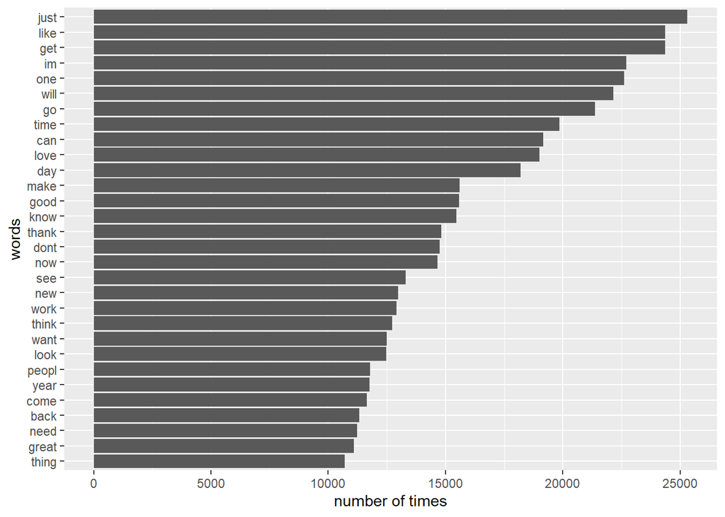

```r
one_gram_token <- tokenize_ngrams(lines_corpus$content,n=1)
one_gram_token <- data.frame(id = 1:length(unlist(one_gram_token)),token = unlist(one_gram_token)) %>% count(token,sort =TRUE)

ggplot(data=head(one_gram_token,30), aes(x = n, y=reorder(token,n))) + geom_bar(stat="identity") + xlab("number of times") + ylab("words")
```

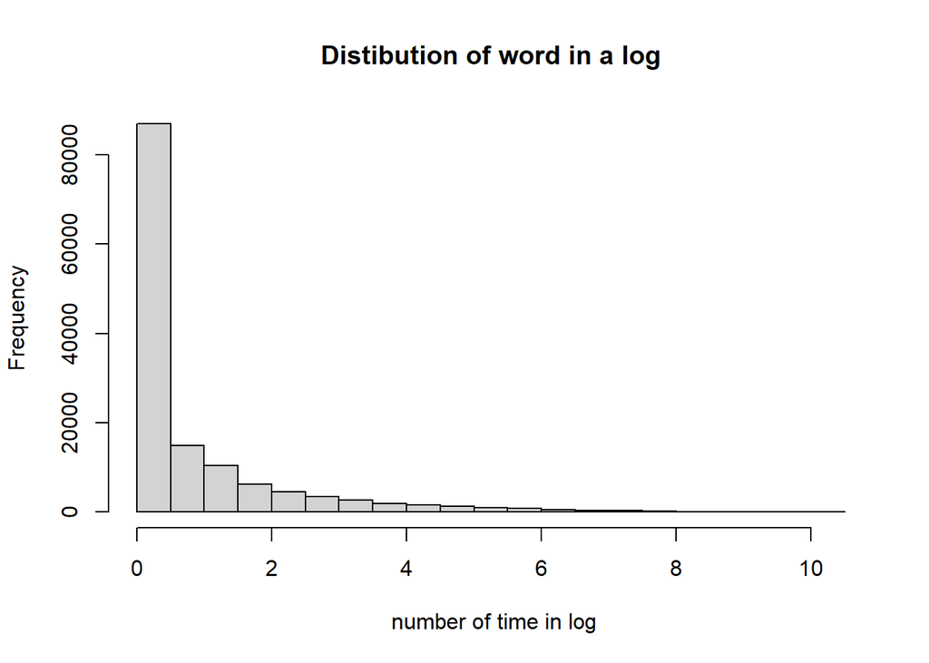

```r
hist(log(one_gram_token$n), main = "Distibution of word in a log",xlab = " number of time in log")
```

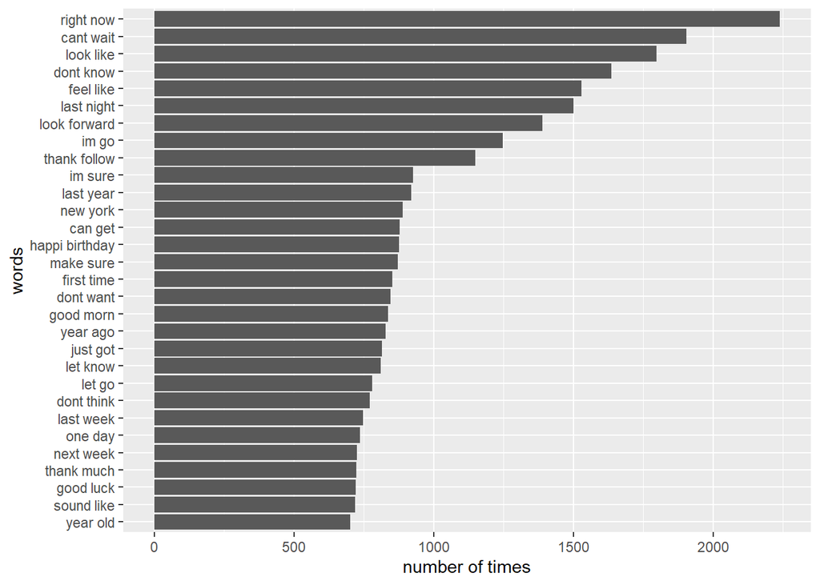

```r
two_gram_token <- tokenize_ngrams(lines_corpus$content,n=2)
two_gram_token <- data.frame(id = 1:length(unlist(two_gram_token)),token = unlist(two_gram_token)) %>% count(token,sort =TRUE)

ggplot(data=head(two_gram_token,30), aes(x = n, y=reorder(token,n))) + geom_bar(stat="identity") + xlab("number of times") + ylab("words")
```

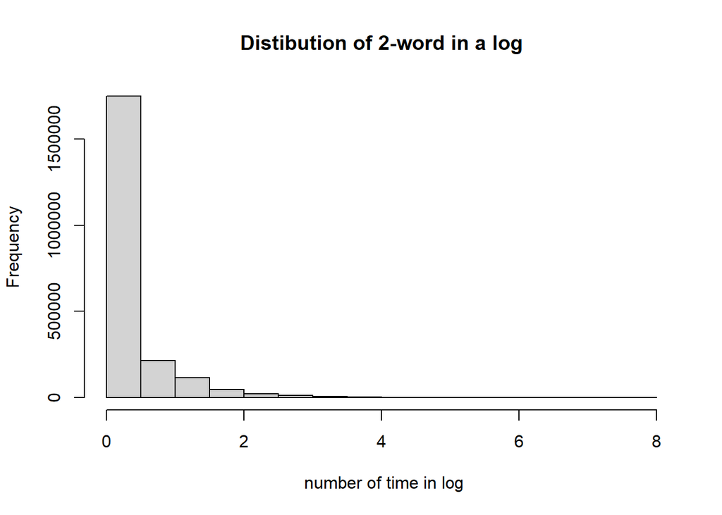

```r
hist(log(two_gram_token$n),main = "Distibution of 2-word in a log",xlab = " number of time in log")
```

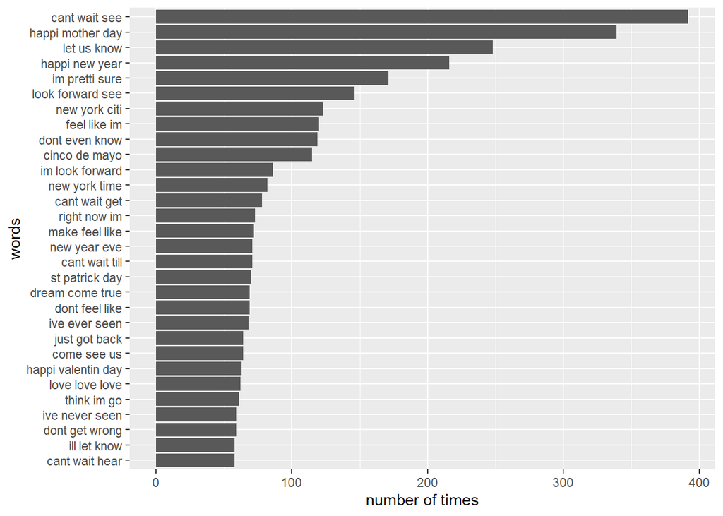

```r
three_gram_token <- tokenize_ngrams(lines_corpus$content,n=3)
three_gram_token <- data.frame(id = 1:length(unlist(three_gram_token)),token = unlist(three_gram_token)) %>% count(token,sort =TRUE)

ggplot(data=head(three_gram_token,30), aes(x = n, y=reorder(token,n))) + geom_bar(stat="identity") + xlab("number of times") + ylab("words")
```

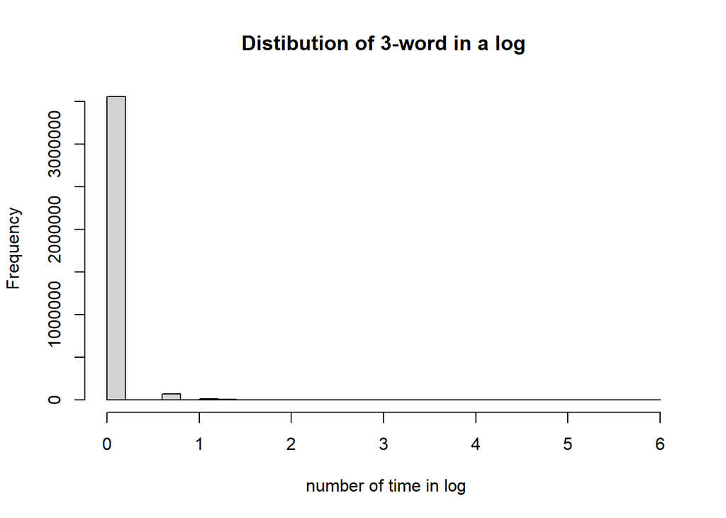

```r
hist(log(three_gram_token$n),main = "Distibution of 3-word in a log",xlab = " number of time in log")
```

As we can see ,some majority of word or combination of words dominate the count of our dataset

Lets count how many unique word cover 50% of the language

```r
countWordPercen <- function(gram_token, percentage){
        count = 0
        sumN = 0
        for ( ns in gram_token$n ){
                if (sumN/sum(gram_token$n) > percentage){
                        return(count)
                }
                else{
                        count = count + 1
                        sumN = sumN + ns
                }
        }

}

countWordPercen(one_gram_token,0.5)
```

```
## [1] 497
```

So there about just under 500(only 0.3%) words that cover 50% of the language. How about 90% ?

```r
countWordPercen(one_gram_token,0.9)
```

```
## [1] 7208
```

More over 5% of the words cover 90% of the language.

## Next step

This part only cover the analysis, the next step will be using the knowledge we gain in the analysis to build a model to predict words. Final steps will be building a shiny app with easy to use interface.